# Bayesian Stats, Meeting 7

Adam Clark

2025-12-01

### Correlated predictors

Below is the code from the case that we discussed at the end of last class – i.e. on why optimisers like MCMC tend to give you more honest estimates of paramter values and their uncertainty. If we simulate a case with two correlated variables $X$ and $Z$, and then try to estimate their effect on variable $Y$, we find that the standard lm function underestaimtes the uncertainty in parameter values – but if we apply boostrapping, we get fatter intervals that account for the added uncertainty caused by the covariance.

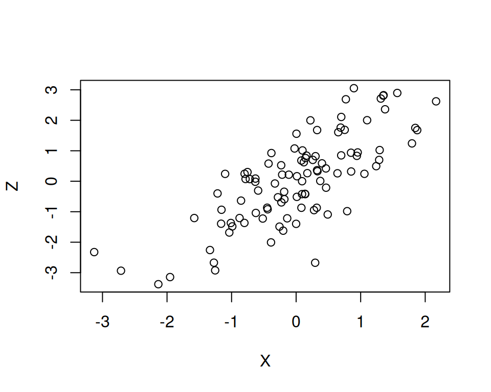

```r
set.seed(123123)
n = 100
X = rnorm(n)
Z = rnorm(n)+X

plot(X,Z)
```

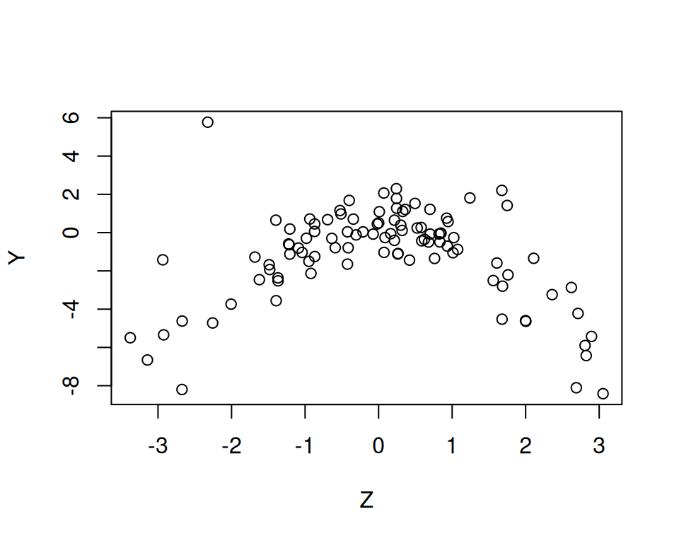

```r
Y = rnorm(n)+X^2-Z^2
plot(Y~Z)
```

```r
mod = lm(Y ~ X+Z)
summary(mod)
```

```
##
## Call:
## lm(formula = Y ~ X + Z)
##
## Residuals:
##     Min      1Q  Median      3Q     Max
## -7.2226 -1.0507  0.6363  1.5181  6.3517
##
## Coefficients:
##             Estimate Std. Error t value Pr(>|t|)
## (Intercept) -1.13008    0.24950  -4.529 1.68e-05 ***
## X           -0.12272    0.40495  -0.303    0.762
## Z           -0.07137    0.26726  -0.267    0.790
## ---
## Signif. codes:  0 '***' 0.001 '**' 0.01 '*' 0.05 '.' 0.1 ' ' 1
##
## Residual standard error: 2.493 on 97 degrees of freedom
## Multiple R-squared:  0.007046,   Adjusted R-squared:  -0.01343
## F-statistic: 0.3442 on 2 and 97 DF,  p-value: 0.7097
```

```r
niter = 1000
boot_summary = matrix(nrow = niter, ncol = 2)
colnames(boot_summary) = c("bX", "bZ")

for(i in 1:niter) {
  ps = sample(n, rep = T)
  mod_boot = lm(Y[ps] ~ X[ps]+Z[ps])
  boot_summary[i,] = unname(c(coef(mod_boot)[2:3]))
}

# note the correlation among model terms - i.e.
# when the slope for X is steep, the slope for Y isn't.
plot(boot_summary)

mod_boot = lm(bZ~bX, data = data.frame(boot_summary))
summary(mod_boot)
```

```
##
## Call:
## lm(formula = bZ ~ bX, data = data.frame(boot_summary))
##
## Residuals:
##      Min       1Q   Median       3Q      Max
## -0.80339 -0.18167 -0.00309  0.17100  0.86495
##
## Coefficients:
##              Estimate Std. Error t value Pr(>|t|)
## (Intercept) -0.149633   0.008483  -17.64   <2e-16 ***
## bX          -0.521367   0.014751  -35.34   <2e-16 ***
## ---
## Signif. codes:  0 '***' 0.001 '**' 0.01 '*' 0.05 '.' 0.1 ' ' 1
##
## Residual standard error: 0.2655 on 998 degrees of freedom
## Multiple R-squared:  0.5559, Adjusted R-squared:  0.5555
## F-statistic:  1249 on 1 and 998 DF,  p-value: < 2.2e-16
```

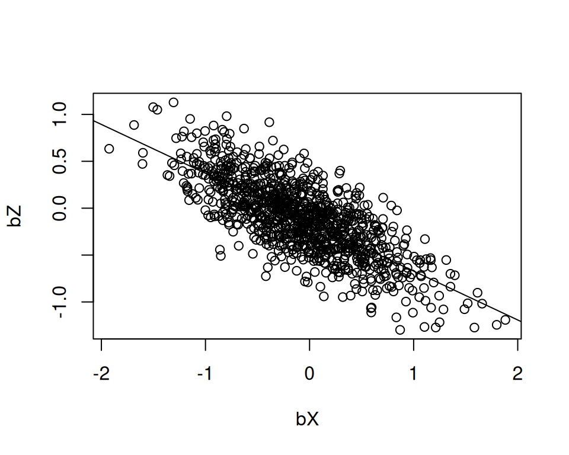

```r
abline(mod_boot)
```

```r
# note, the uncertainty estimates are much higher in the
# bootstrapped estimates, since these are (better) accounting
# for the covariance between
apply(boot_summary, 2, mean)
```

```
##          bX          bZ
## -0.08156638 -0.10710699
```

```r
apply(boot_summary, 2, sd)
```

```
##        bX        bZ
## 0.5695413 0.3982598
```

```r
summary(mod)
```

```
##
## Call:
## lm(formula = Y ~ X + Z)
##
## Residuals:
##     Min      1Q  Median      3Q     Max
## -7.2226 -1.0507  0.6363  1.5181  6.3517
##
## Coefficients:
##             Estimate Std. Error t value Pr(>|t|)
## (Intercept) -1.13008    0.24950  -4.529 1.68e-05 ***
## X           -0.12272    0.40495  -0.303    0.762
## Z           -0.07137    0.26726  -0.267    0.790
## ---
## Signif. codes:  0 '***' 0.001 '**' 0.01 '*' 0.05 '.' 0.1 ' ' 1
##
## Residual standard error: 2.493 on 97 degrees of freedom
## Multiple R-squared:  0.007046,   Adjusted R-squared:  -0.01343
## F-statistic: 0.3442 on 2 and 97 DF,  p-value: 0.7097
```

As noted by Manuele (this was news to me), the “standard” method for calculating standard errors for parameter estimates in OLS, and as it is implemented in lm, actually does deal with impacts of covariance, so long as the model is fully linear. E.g. if you take the example above and simplify the function for $Y$ to make it linear (i.e. $Y = X+Z$), then the standard error estimates from bootstrapping and from the lm function are identical.

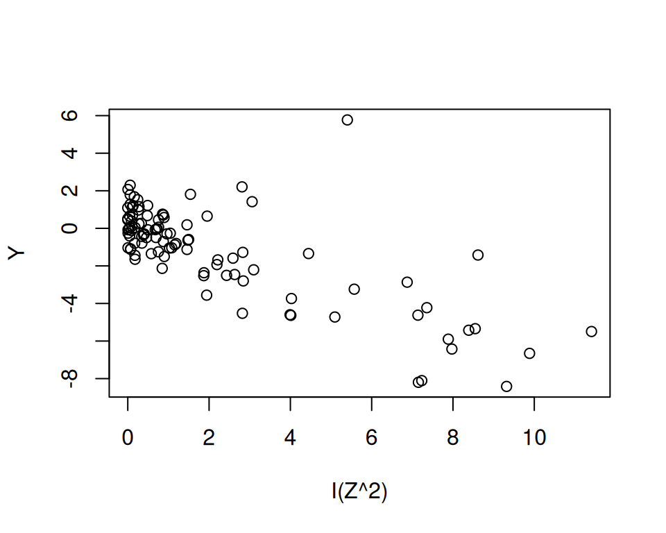

```r
plot(Y~I(Z^2))
```

```r
mod = lm(Y ~ I(X^2)+I(Z^2))
summary(mod)
```

```
##
## Call:
## lm(formula = Y ~ I(X^2) + I(Z^2))
##
## Residuals:
##      Min       1Q   Median       3Q      Max
## -3.03855 -0.65673  0.04363  0.65110  2.60891
##
## Coefficients:
##              Estimate Std. Error t value Pr(>|t|)
## (Intercept) -0.009985   0.125417   -0.08    0.937
## I(X^2)       1.057599   0.079626   13.28   <2e-16 ***
## I(Z^2)      -0.998154   0.043325  -23.04   <2e-16 ***
## ---
## Signif. codes:  0 '***' 0.001 '**' 0.01 '*' 0.05 '.' 0.1 ' ' 1
##
## Residual standard error: 0.9833 on 97 degrees of freedom
## Multiple R-squared:  0.8455, Adjusted R-squared:  0.8423
## F-statistic: 265.5 on 2 and 97 DF,  p-value: < 2.2e-16
```

```r
niter = 1000
boot_summary = matrix(nrow = niter, ncol = 2)
colnames(boot_summary) = c("bX", "bZ")

for(i in 1:niter) {
  ps = sample(n, rep = T)
  mod_boot = lm(Y[ps] ~ I(X[ps]^2)+I(Z[ps]^2))
  boot_summary[i,] = unname(c(coef(mod_boot)[2:3]))
}

# note the correlation among model terms - i.e.
# when the slope for X is steep, the slope for Y isn't.
plot(boot_summary)

mod_boot = lm(bZ~bX, data = data.frame(boot_summary))
summary(mod_boot)
```

```
##
## Call:
## lm(formula = bZ ~ bX, data = data.frame(boot_summary))
##
## Residuals:
##       Min        1Q    Median        3Q       Max
## -0.131161 -0.022026 -0.000136  0.023625  0.113908
##
## Coefficients:
##             Estimate Std. Error t value Pr(>|t|)
## (Intercept) -0.64730    0.01275  -50.76   <2e-16 ***
## bX          -0.33305    0.01219  -27.33   <2e-16 ***
## ---
## Signif. codes:  0 '***' 0.001 '**' 0.01 '*' 0.05 '.' 0.1 ' ' 1
##
## Residual standard error: 0.03431 on 998 degrees of freedom
## Multiple R-squared:  0.428,  Adjusted R-squared:  0.4275
## F-statistic: 746.9 on 1 and 998 DF,  p-value: < 2.2e-16
```

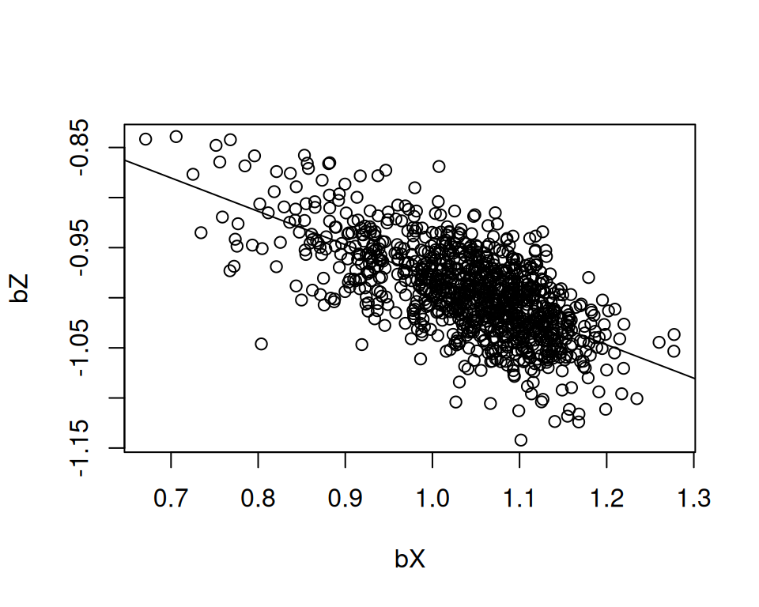

```r
abline(mod_boot)
```

```r
# note, the uncertainty estimates are much higher in the
# bootstrapped estimates, since these are (better) accounting
# for the covariance between
apply(boot_summary, 2, mean)
```

```
##         bX         bZ
##  1.0426789 -0.9945641
```

```r
apply(boot_summary, 2, sd)
```

```
##         bX         bZ
## 0.08907635 0.04534535
```

```r
summary(mod)
```

```
##
## Call:
## lm(formula = Y ~ I(X^2) + I(Z^2))
##
## Residuals:
##      Min       1Q   Median       3Q      Max
## -3.03855 -0.65673  0.04363  0.65110  2.60891
##
## Coefficients:
##              Estimate Std. Error t value Pr(>|t|)
## (Intercept) -0.009985   0.125417   -0.08    0.937
## I(X^2)       1.057599   0.079626   13.28   <2e-16 ***
## I(Z^2)      -0.998154   0.043325  -23.04   <2e-16 ***
## ---
## Signif. codes:  0 '***' 0.001 '**' 0.01 '*' 0.05 '.' 0.1 ' ' 1
##
## Residual standard error: 0.9833 on 97 degrees of freedom
## Multiple R-squared:  0.8455, Adjusted R-squared:  0.8423
## F-statistic: 265.5 on 2 and 97 DF,  p-value: < 2.2e-16
```

This shows that the “real” problem with our initial example was one of definition, rather than functional for. That is, we fit the “wrong” model to the data (by assuming a linear relationship when the relationship was actually quadratic). So long as we are able to find a transformation that coerces the system back into a linear form, though, regular old regression should work fine to identify model paramter mean values and standard errors.